# Project Python Foundations: FoodHub Data Analysis

**Marks: 60**

### Context

The number of restaurants in New York is increasing day by day. Lots of students and busy professionals rely on those restaurants due to their hectic lifestyles. Online food delivery service is a great option for them. It provides them with good food from their favorite restaurants. A food aggregator company FoodHub offers access to multiple restaurants through a single smartphone app.

The app allows the restaurants to receive a direct online order from a customer. The app assigns a delivery person from the company to pick up the order after it is confirmed by the restaurant. The delivery person then uses the map to reach the restaurant and waits for the food package. Once the food package is handed over to the delivery person, he/she confirms the pick-up in the app and travels to the customer's location to deliver the food. The delivery person confirms the drop-off in the app after delivering the food package to the customer. The customer can rate the order in the app. The food aggregator earns money by collecting a fixed margin of the delivery order from the restaurants.

### Objective

The food aggregator company has stored the data of the different orders made by the registered customers in their online portal. They want to analyze the data to get a fair idea about the demand of different restaurants which will help them in enhancing their customer experience. Perform data analysis to find answers to these questions that will help the company to improve business.

### Data Description

The data contains the different data related to a food order. The detailed data dictionary is given below.

### Data Dictionary

- order_id: Unique ID of the order
- customer_id: ID of the customer who ordered the food
- restaurant_name: Name of the restaurant
- cuisine_type: Cuisine ordered by the customer
- cost: Cost of the order
- day_of_the_week: Indicates whether the order is placed on a weekday or weekend (The weekday is from Monday to Friday and the weekend is Saturday and Sunday)
- rating: Rating given by the customer out of 5
- food_preparation_time: Time (in minutes) taken by the restaurant to prepare the food. This is calculated by taking the difference between the timestamps of the restaurant's order confirmation and the delivery person's pick-up confirmation.
- delivery_time: Time (in minutes) taken by the delivery person to deliver the food package. This is calculated by taking the difference between the timestamps of the delivery person's pick-up confirmation and drop-off information

### Let us start by importing the required libraries

```python
# import libraries for data manipulation
import numpy as np
import pandas as pd

# import libraries for data visualization
import matplotlib.pyplot as plt
import seaborn as sns
```

### Understanding the structure of the data

```python
# read the data
data = pd.read_csv('foodhub_order.csv')
# returns the first 5 rows
#data.head()
# make a duplicate copy of DataFrame for analysis purposes
df = data.copy()
df.head()
```

|  | order_id | customer_id | restaurant_name | cuisine_type | cost_of_the_order | day_of_the_week | rating | food_preparation_time | delivery_time |
| --- | --- | --- | --- | --- | --- | --- | --- | --- | --- |
| 0 | 1477147 | 337525 | Hangawi | Korean | 30.75 | Weekend | Not given | 25 | 20 |
| 1 | 1477685 | 358141 | Blue Ribbon Sushi Izakaya | Japanese | 12.08 | Weekend | Not given | 25 | 23 |
| 2 | 1477070 | 66393 | Cafe Habana | Mexican | 12.23 | Weekday | 5 | 23 | 28 |
| 3 | 1477334 | 106968 | Blue Ribbon Fried Chicken | American | 29.20 | Weekend | 3 | 25 | 15 |
| 4 | 1478249 | 76942 | Dirty Bird to Go | American | 11.59 | Weekday | 4 | 25 | 24 |

#### Observations:

- The DataFrame has 9 columns as mentioned in the Data Dictionary. Data in each row corresponds to the order placed by a customer.

### **Question 1:** How many rows and columns are present in the data?

```python
df.shape
```

```
(1898, 9)
```

#### Observations:

- There are 1898 rows and 9 columns.

### **Question 2:** What are the datatypes of the different columns in the dataset? (The info() function can be used)

```python
df.info()
```

```
<class 'pandas.core.frame.DataFrame'>
RangeIndex: 1898 entries, 0 to 1897
Data columns (total 9 columns):
 #   Column                 Non-Null Count  Dtype
---  ------                 --------------  -----
 0   order_id               1898 non-null   int64
 1   customer_id            1898 non-null   int64
 2   restaurant_name        1898 non-null   object
 3   cuisine_type           1898 non-null   object
 4   cost_of_the_order      1898 non-null   float64
 5   day_of_the_week        1898 non-null   object
 6   rating                 1898 non-null   object
 7   food_preparation_time  1898 non-null   int64
 8   delivery_time          1898 non-null   int64
dtypes: float64(1), int64(4), object(4)
memory usage: 133.6+ KB
```

#### Observations:

- There are 4 columns of type integer: order_id,customer_id, food_preparation_time, delivery_time.
- There are 4 columns of type object: restaurant_name, cuisine_type, day_of_the_week, rating.
- There is 1 column of type float: cost_of_the_order.
- Though order_id and customer_id columns are of type integer,statistical summary of that data is not meaningful.
- Rating column is type object, as in addition to numbers, it also has text.
- All columns have 1898 observations, so no null values present.

### **Question 3:** Are there any missing values in the data? If yes, treat them using an appropriate method.

```python
df.isnull().sum() # check for missing values
```

```
order_id                 0
customer_id              0
restaurant_name          0
cuisine_type             0
cost_of_the_order        0
day_of_the_week          0
rating                   0
food_preparation_time    0
delivery_time            0
dtype: int64
```

```python
df.isnull().values.any() #check for missing values
```

```
False
```

#### Observations:

- There are no missing values in any column of DataFrame.

```python
df[df.duplicated()].shape[0]  #check for duplicate rows
```

```
0
```

#### Observations:

- There are no duplicate rows in DataFrame.

### **Question 4:** Check the statistical summary of the data. What is the minimum, average, and maximum time it takes for food to be prepared once an order is placed?

```python
df.describe(include="all") # print statistical summary of all columns
```

|  | order_id | customer_id | restaurant_name | cuisine_type | cost_of_the_order | day_of_the_week | rating | food_preparation_time | delivery_time |
| --- | --- | --- | --- | --- | --- | --- | --- | --- | --- |
| count | 1.898000e+03 | 1898.000000 | 1898 | 1898 | 1898.000000 | 1898 | 1898 | 1898.000000 | 1898.000000 |
| unique | NaN | NaN | 178 | 14 | NaN | 2 | 4 | NaN | NaN |
| top | NaN | NaN | Shake Shack | American | NaN | Weekend | Not given | NaN | NaN |
| freq | NaN | NaN | 219 | 584 | NaN | 1351 | 736 | NaN | NaN |
| mean | 1.477496e+06 | 171168.478398 | NaN | NaN | 16.498851 | NaN | NaN | 27.371970 | 24.161749 |
| std | 5.480497e+02 | 113698.139743 | NaN | NaN | 7.483812 | NaN | NaN | 4.632481 | 4.972637 |
| min | 1.476547e+06 | 1311.000000 | NaN | NaN | 4.470000 | NaN | NaN | 20.000000 | 15.000000 |
| 25% | 1.477021e+06 | 77787.750000 | NaN | NaN | 12.080000 | NaN | NaN | 23.000000 | 20.000000 |
| 50% | 1.477496e+06 | 128600.000000 | NaN | NaN | 14.140000 | NaN | NaN | 27.000000 | 25.000000 |
| 75% | 1.477970e+06 | 270525.000000 | NaN | NaN | 22.297500 | NaN | NaN | 31.000000 | 28.000000 |
| max | 1.478444e+06 | 405334.000000 | NaN | NaN | 35.410000 | NaN | NaN | 35.000000 | 33.000000 |

- Minimum food preparation time: 20 minutes
- Average food preparation time: 27.37 minutes
- Maximum food preparation time: 35 minutes

#### Observations:

- Statistical analysis of Order_id and customer_id columns do not yield any meaningful insights, as they are unique identifiers for each order and customer.
- There are 178 unique restaurant names.
- Shake Shack is the most popular restaurant, serving American cuisine, it has occurred 219 times in the DataFrame.
- There are 14 unique cuisine types available through the app, American being the most popular, occurs 584 times in the DataFrame.
- Weekend is more popular than weekday for food orders, occuring 1351 times in the DataFrame.
- There are 4 unique ratings present in the DataFrame, 3,4,5,Not Given. 'Not given' is the most commonly occuring rating type, implying lot of orders go unrated (736 out of 1898).
- Cost of orders placed ranges between minimum 4.47 dollars to 35.41 dollars, with an average of 16.49 dollars.
- Delivery time ranges between minimum 15 to max 33 minutes, with an average of 24 minutes.

### **Question 5:** How many orders are not rated?

```python
df['rating'].unique()  # no of unique ratings
```

```
array(['Not given', '5', '3', '4'], dtype=object)
```

```python
#number of orders that are not rated

df['rating'].value_counts()   #returns all unique rating counts

#this can also be observed from statistical summary of DataFrame (top rating observed is 'Not given' with frequency of 736)
#df[df['rating']=='Not given'].shape[0] # --> returns 736
```

```
Not given    736
5            588
4            386
3            188
Name: rating, dtype: int64
```

#### Observations:

- 736 out of 1898 orders are not rated, which is 38%. It is not suitable to use mean, median or mode to impute this column.

### Exploratory Data Analysis (EDA)

### **Question 6:** Explore all the variables and provide observations on their distributions. (Generally, histograms, boxplots, countplots, etc. are used for univariate exploration.)

#### Order id

```python
df['order_id'].nunique() # check unique order ids
```

```
1898
```

- There are 1898 unique order ids. Dataset has 1898 rows, no duplicate orders are present.

#### Customer id

```python
df['customer_id'].nunique() # check unique customer ids
```

```
1200
```

- There are 1200 unique customers, with multiple order ids associated with them.

```python
df['customer_id'].value_counts().head(10) # Top 10 customers based on number of orders
```

```
52832     13
47440     10
83287      9
250494     8
259341     7
82041      7
65009      7
276192     7
97079      6
97991      6
Name: customer_id, dtype: int64
```

#### Restaurant Name

```python
df['restaurant_name'].nunique() #check unique restaurants
```

```
178
```

- There are 178 unique restaurants.

#### Cuisine Type

```python
df['cuisine_type'].nunique() #check unique cuisine types
```

```
14
```

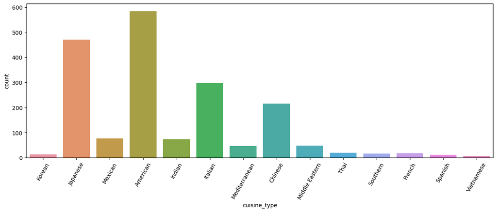

```python
#Observations on cuisine type
plt.figure(figsize = (15,5))
sns.countplot(data=data,x='cuisine_type')
plt.xticks(rotation = 60);
plt.show()
```

#### Observations:

- There are 14 unique cuisine types.
- American, Japanese, Italian,Chinese, Mexican are the top 5 popular cuisines.
- Indian, Middle Eastern, Mediterranean are moderately popular.
- Thai,Southern,French, Spanish, Korean are even less popular with Vietnamese being the least popular.

#### Cost of Orders

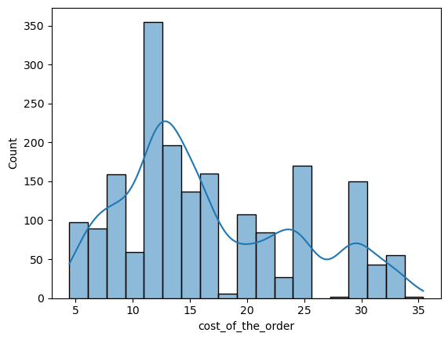

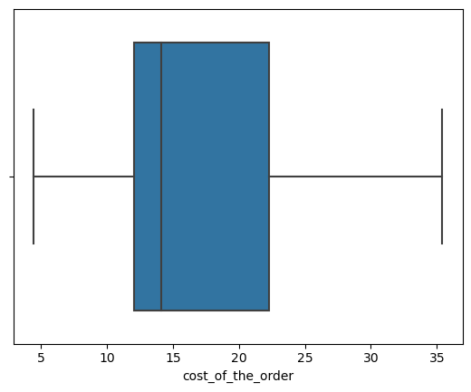

```python
#Observations on cost of order
sns.histplot(data=data,x='cost_of_the_order', kde = True)
plt.show()
sns.boxplot(data=data,x='cost_of_the_order')
plt.show()
```

#### Day of the week

```python
df['day_of_the_week'].value_counts() # check for unique values in day of the week
```

```
Weekend    1351
Weekday     547
Name: day_of_the_week, dtype: int64
```

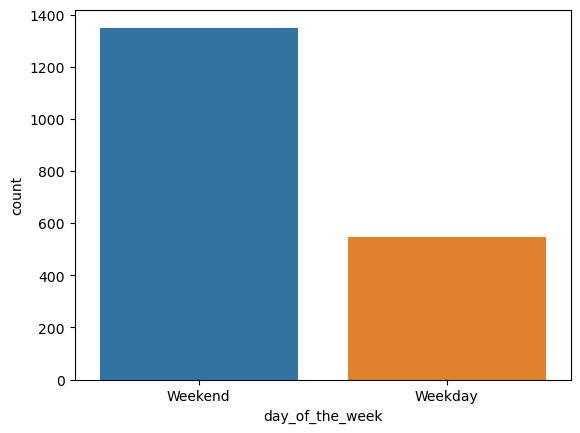

```python
sns.countplot(data = data, x = 'day_of_the_week');
```

#### Observations:

- Weekend(1351 orders) is more popular than weekdays(547) for delivery orders.
- It will help to understand why weekday orders are low.

#### Rating

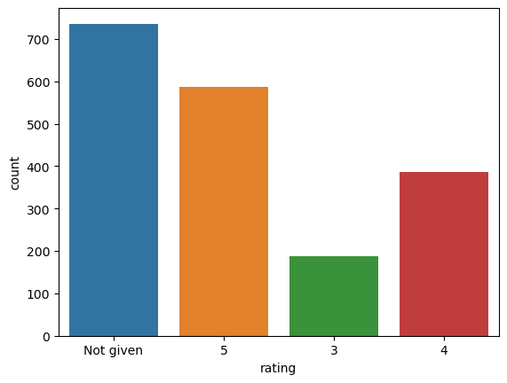

```python
sns.countplot(data=data,x='rating')
plt.show()
```

#### Food Preparation Time

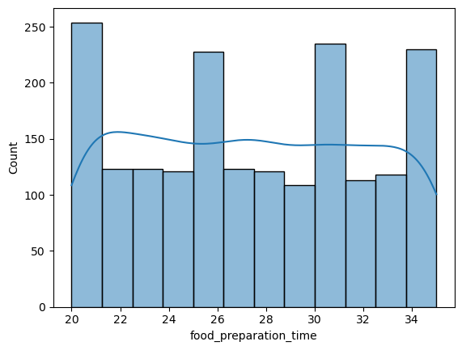

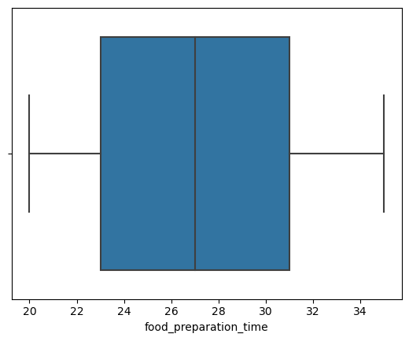

```python
sns.histplot(data=data,x='food_preparation_time', kde = True)
plt.show()
sns.boxplot(data=data,x='food_preparation_time')
plt.show()
```

#### Delivery Time

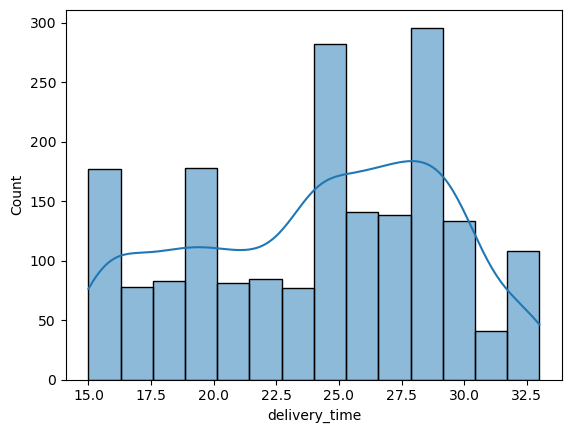

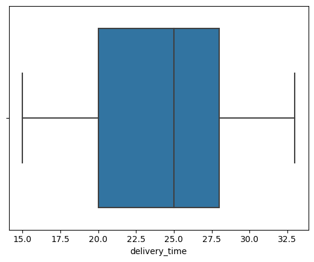

```python
sns.histplot(data=data,x='delivery_time', kde = True)
plt.show()
sns.boxplot(data=data,x='delivery_time')
plt.show()
```

### **Question 7**: Which are the top 5 restaurants in terms of the number of orders received?

```python
# we know there are 178 unique restaurants from statistical summary
a = df[['restaurant_name','order_id']]   # create dataframe subset of restaurants and order_id
b = df.groupby('restaurant_name')[['order_id']].count()  # group restaurants by order count
c = b.sort_values('order_id', ascending = False) # sort resulting dataset on order count
c.head() # top 5
```

| restaurant_name | order_id |
| --- | --- |
| Shake Shack | 219 |
| The Meatball Shop | 132 |
| Blue Ribbon Sushi | 119 |
| Blue Ribbon Fried Chicken | 96 |
| Parm | 68 |

#### Observations:

Top 5 restaurants in terms of orders received are: Shake Shack, The Meatball Shop, Blue Ribbon Sushi, Blue Ribbon Fried Chicken,Parm

### **Question 8**: Which is the most popular cuisine on weekends?

```python
df_weekend = df[df['day_of_the_week'] == 'Weekend'] # filter dataframe for weekend
df_weekend['cuisine_type'].value_counts() # count unique values in cuisine type
```

```
American          415
Japanese          335
Italian           207
Chinese           163
Mexican            53
Indian             49
Mediterranean      32
Middle Eastern     32
Thai               15
French             13
Korean             11
Southern           11
Spanish            11
Vietnamese          4
Name: cuisine_type, dtype: int64
```

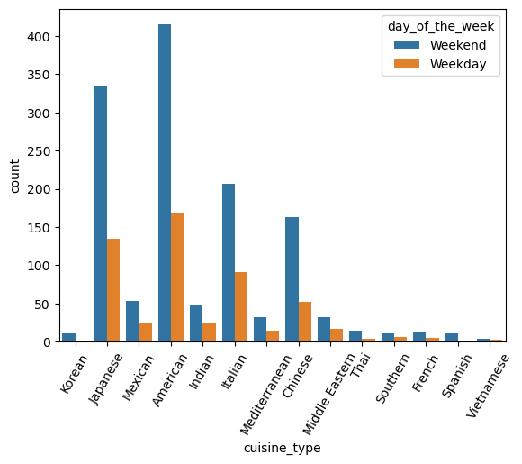

```python
sns.countplot(x = 'cuisine_type', data = df, hue = 'day_of_the_week')
plt.xticks(rotation = 60);
```

#### Observations:

- American is the most popular cuisine on weekends.

### **Question 9**: What percentage of the orders cost more than 20 dollars?

```python
df_greater_than_20 = df[df['cost_of_the_order']>20] # filter dataframe for orders more than 20 dollars
df_greater_than_20.shape[0]  # number of rows with orders more than 20 dollars
percentage = (df_greater_than_20.shape[0] / df.shape[0]) * 100  # no of orders with cost over 20 divided by total orders
round(percentage,2) # percentage rounded to 2 decimals
```

```
29.24
```

#### Observations:

- About 29% of orders, cost more than 20 dollars.

### **Question 10**: What is the mean order delivery time? [1 mark]

```python
#Mean order delivery time is 24.16 minutes as obtained from statistical summary or using code below
round(df['delivery_time'].mean(),2)
```

```
24.16
```

#### Observations:

- Mean order delivery time is 24.16 minutes.

### **Question 11:** The company has decided to give 20% discount vouchers to the top 3 most frequent customers. Find the IDs of these customers and the number of orders they placed.

```python
# top 3 most frequent customers using value_count function
df['customer_id'].value_counts().head(3)
```

```
52832    13
47440    10
83287     9
Name: customer_id, dtype: int64
```

```python
# top 3 most frequent customers using groupby function
a = df.groupby('customer_id')[['order_id']].count()  # subset of customer ids grouped by order count
b = a.sort_values('order_id', ascending = False) # sort descending by orders to find top 3
b.head(3) # top 3 customers
```

| customer_id | order_id |
| --- | --- |
| 52832 | 13 |
| 47440 | 10 |
| 83287 | 9 |

#### Observations:

- Top 3 customer IDs receiving 20% FoodHub discount voucher are 52832 (13 orders), 47440(10 orders), 83287(9 orders).

### **Question 12**: Perform a multivariate analysis to explore relationships between the important variables in the dataset. (It is a good idea to explore relations between numerical variables as well as relations between numerical and categorical variables)

#### Cuisine vs Cost of Order

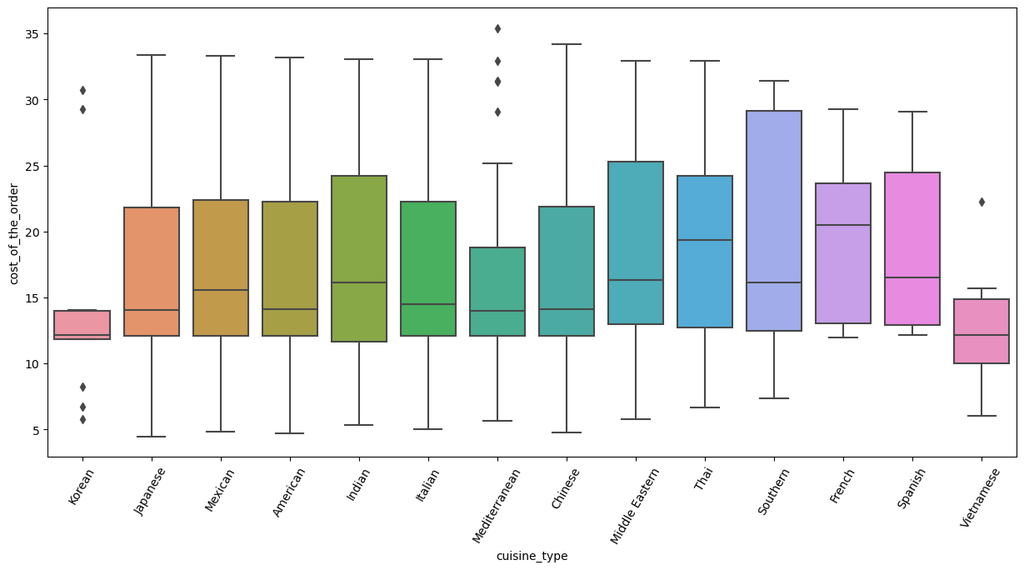

```python
# Relationship between cost of the order and cuisine type using box plot
plt.figure(figsize=(15,7))
sns.boxplot(x = "cuisine_type", y = "cost_of_the_order", data = df)
plt.xticks(rotation = 60)
plt.show()
```

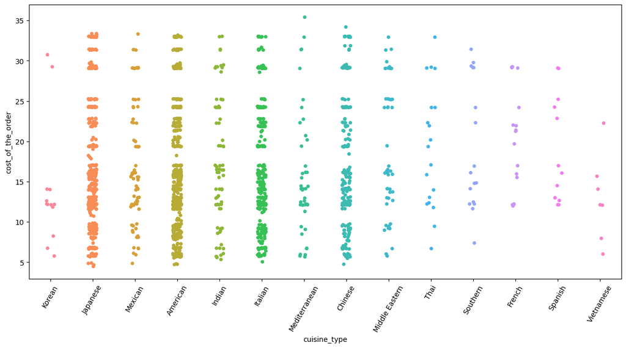

```python
# Relationship between cuisine and cost of order using strip plot
plt.figure(figsize=(15,7))
sns.stripplot(data=df,x='cuisine_type',y='cost_of_the_order',jitter=True)
plt.xticks(rotation = 60)
plt.show()
```

#### Cuisine vs Food Preparation Time

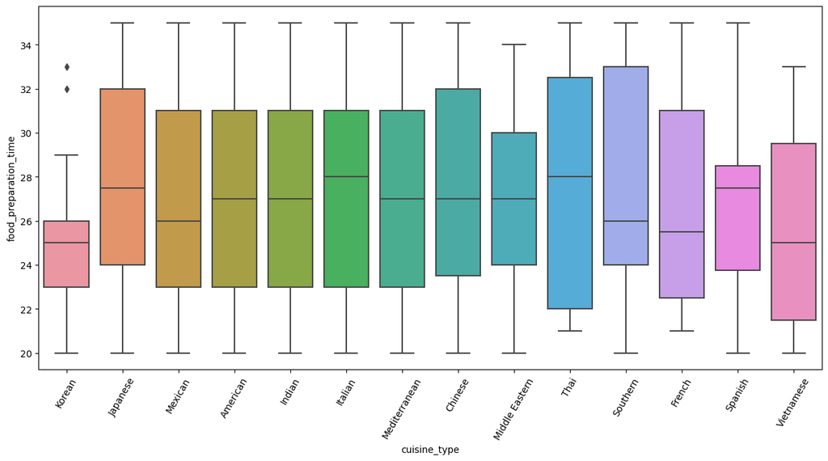

```python
# Relationship between food preparation time and cuisine type using box plot
plt.figure(figsize=(15,7))
sns.boxplot(x = "cuisine_type", y = "food_preparation_time", data = df)
plt.xticks(rotation = 60)
plt.show()
```

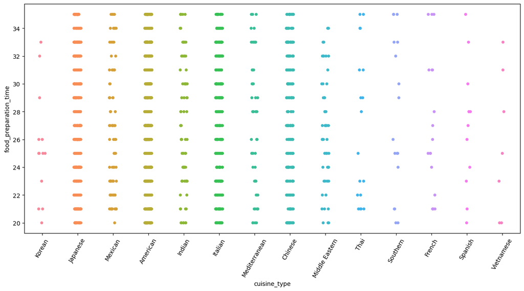

```python
# Relationship between cuisine type and food preparation time using strip plot

plt.figure(figsize=(15,7))
sns.stripplot(data=df,x='cuisine_type',y='food_preparation_time',jitter=True)
plt.xticks(rotation = 60)
plt.show()
```

#### Observations on Cuisine vs Food Preparation Time

- American, Indian, Mediterranean, Chinese, Middle Eastern cuisines have about the same median food preparation time, between 27 and 28 minutes.
- Italian and Thai are the top two cuisines in terms of median food prep time, about 28 minutes.
- Korean and Vietnamese are the bottom two in terms of median food prep time, about 25 minutes.
- Korean shows some outliers, there are some Korean restaurants with food prep time 32-33 minutes.
- No outliers observed in other cuisine types.

#### Day of the Week vs Delivery Time

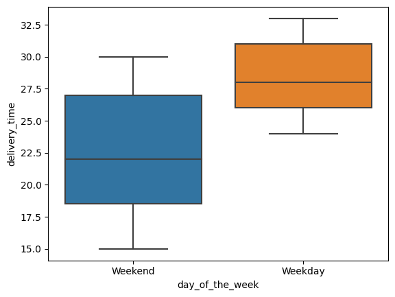

```python
# Relationship between Day of the week and Delivery time
sns.boxplot(x = "day_of_the_week", y = "delivery_time", data = df)
plt.show()
```

#### Observations on Day of the week vs Delivery Time

- Median weekend delivery time is about 22 minutes, Median weekday delivery time is about 28 minutes.
- Q3 is about 27 minutes for weekend delivery, Q3 is about 31 minutes for weekday delivery.
- Weekend delivery times seem more efficient compared to weekday deliveries.

#### Rating vs Delivery Time

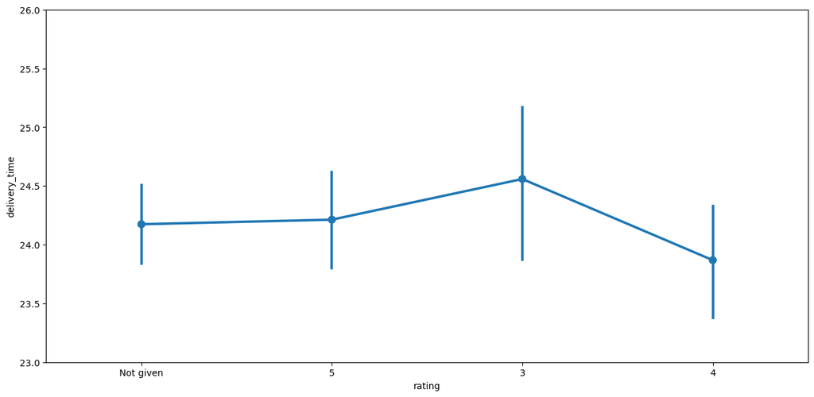

```python
# Relationship between rating and delivery time
plt.figure(figsize=(15, 7))
sns.pointplot(x = 'rating', y = 'delivery_time', data = df)
plt.ylim(23, 26)
plt.show()
```

#### Rating vs Food Preparation Time

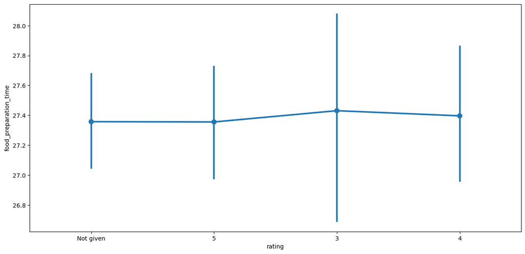

```python
# Relationship between rating and food preparation time
plt.figure(figsize=(15, 7))
sns.pointplot(x = 'rating', y = 'food_preparation_time', data = df)
plt.show()
```

#### Rating vs Cost of the Order

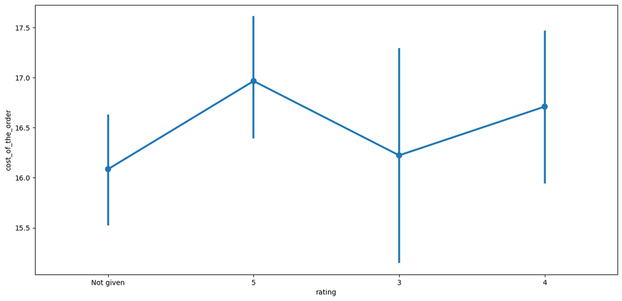

```python
# Relationship between rating and cost of the order
plt.figure(figsize=(15, 7))
sns.pointplot(x = 'rating', y = 'cost_of_the_order', data = df)
plt.show()
```

#### Correlation among variables

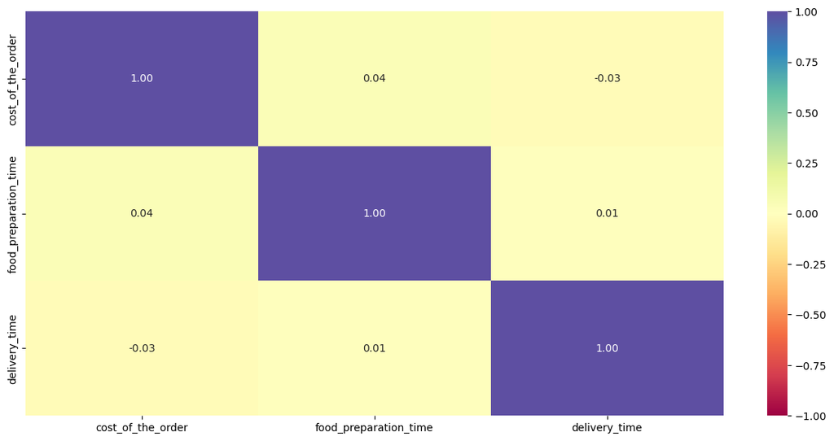

```python
# heatmap to see correlation between cost of order, food prep time, delivery time
col_list = ['cost_of_the_order', 'food_preparation_time', 'delivery_time']
plt.figure(figsize=(15, 7))
sns.heatmap(df[col_list].corr(), annot=True, vmin=-1, vmax=1, fmt=".2f", cmap="Spectral")
plt.show()
```

#### Observations on correlation among variables

- There is not a strong correlation between the 3 numeric variables in dataset.
- We need more variables to identify patterns and relationships. Lets try to calculate revenue generated by restaurants.

#### Revenue generated by restaurants

```python
# revenue generated by restaurants by adding cost of all orders
df_rev1 = df.groupby(['order_id'])['cost_of_the_order'].sum().sort_values(ascending = False).reset_index()
#rename cost_of_order column to say revenue
df_rev1.rename(columns={'cost_of_the_order':'revenue'},inplace=True)
df_rev1
```

|  | order_id | revenue |
| --- | --- | --- |
| 0 | 1477814 | 35.41 |
| 1 | 1477665 | 34.19 |
| 2 | 1477700 | 33.37 |
| 3 | 1476970 | 33.37 |
| 4 | 1478329 | 33.32 |
| ... | ... | ... |
| 1893 | 1477786 | 4.75 |
| 1894 | 1477790 | 4.75 |
| 1895 | 1477788 | 4.71 |
| 1896 | 1476877 | 4.66 |
| 1897 | 1477349 | 4.47 |

1898 rows × 2 columns

```python
# merge dataframe with revenue column to original dataframe
df_revenue = pd.merge(df,df_rev1, on = 'order_id', how = 'outer')
df_revenue
```

|  | order_id | customer_id | restaurant_name | cuisine_type | cost_of_the_order | day_of_the_week | rating | food_preparation_time | delivery_time | revenue |
| --- | --- | --- | --- | --- | --- | --- | --- | --- | --- | --- |
| 0 | 1477147 | 337525 | Hangawi | Korean | 30.75 | Weekend | Not given | 25 | 20 | 30.75 |
| 1 | 1477685 | 358141 | Blue Ribbon Sushi Izakaya | Japanese | 12.08 | Weekend | Not given | 25 | 23 | 12.08 |
| 2 | 1477070 | 66393 | Cafe Habana | Mexican | 12.23 | Weekday | 5 | 23 | 28 | 12.23 |
| 3 | 1477334 | 106968 | Blue Ribbon Fried Chicken | American | 29.20 | Weekend | 3 | 25 | 15 | 29.20 |
| 4 | 1478249 | 76942 | Dirty Bird to Go | American | 11.59 | Weekday | 4 | 25 | 24 | 11.59 |
| ... | ... | ... | ... | ... | ... | ... | ... | ... | ... | ... |
| 1893 | 1476701 | 292602 | Chipotle Mexican Grill $1.99 Delivery | Mexican | 22.31 | Weekend | 5 | 31 | 17 | 22.31 |
| 1894 | 1477421 | 397537 | The Smile | American | 12.18 | Weekend | 5 | 31 | 19 | 12.18 |
| 1895 | 1477819 | 35309 | Blue Ribbon Sushi | Japanese | 25.22 | Weekday | Not given | 31 | 24 | 25.22 |
| 1896 | 1477513 | 64151 | Jack's Wife Freda | Mediterranean | 12.18 | Weekday | 5 | 23 | 31 | 12.18 |
| 1897 | 1478056 | 120353 | Blue Ribbon Sushi | Japanese | 19.45 | Weekend | Not given | 28 | 24 | 19.45 |

1898 rows × 10 columns

#### Check correlation using revenue

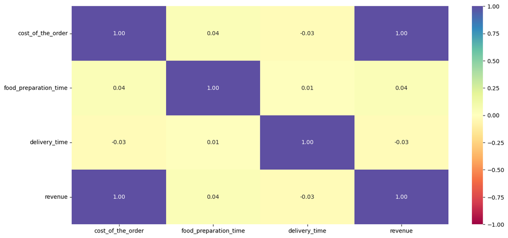

```python
# heatmap to see correlation between cost of order, food prep time, delivery time, revenue
col_list = ['cost_of_the_order', 'food_preparation_time', 'delivery_time', 'revenue']
plt.figure(figsize=(15, 7))
sns.heatmap(df_revenue[col_list].corr(), annot=True, vmin=-1, vmax=1, fmt=".2f", cmap="Spectral")
plt.show()
```

- Heatmap still does not present a strong correlation among the available numeric variables.
- More variables are needed to extract meaningful correlation.

#### Cuisine type vs Revenue

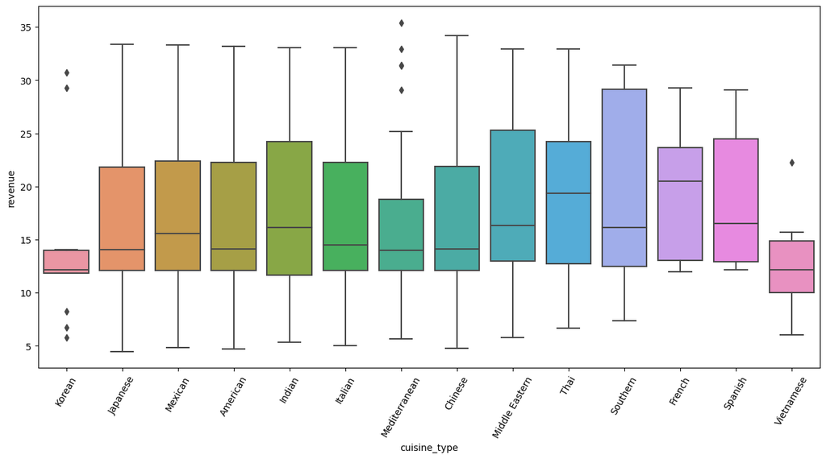

```python
# Relationship between cuisine_type and revenue
plt.figure(figsize=(15, 7))
sns.boxplot(x = 'cuisine_type',y='revenue', data = df_revenue)
plt.xticks(rotation = 60)
plt.show()
```

#### Observations on cuisine type and revenue

- Thai and French cuisines have top 2 median revenues,followed by Mexican,Indian,Middle Eastern,Southern,Spanish.
- Korean and Vietnamese generate least median revenue.
- Korean, Mediterranean and Vietnamese cuisines show some outliers in revenue.

#### Rating vs Revenue

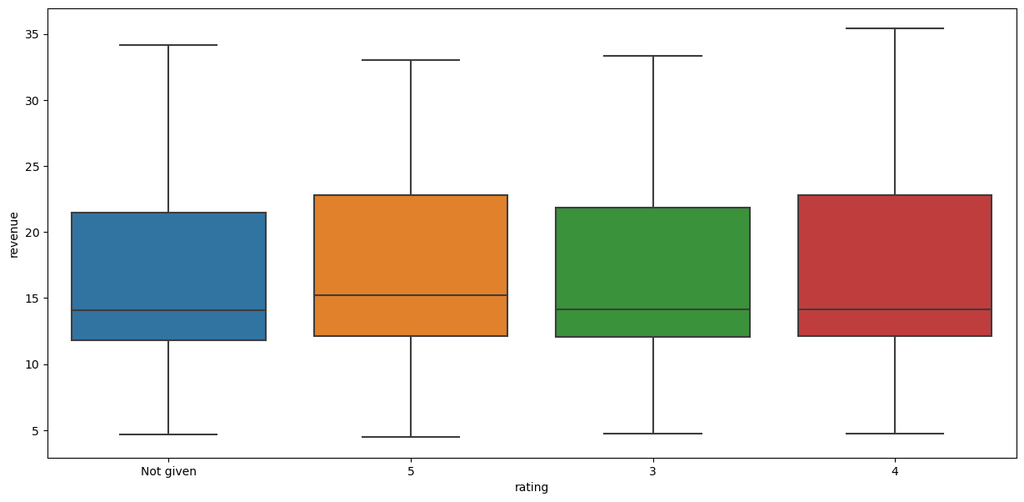

```python
# Relationship between rating and revenue
plt.figure(figsize=(15, 7))
sns.boxplot(x = 'rating', y = 'revenue', data = df_revenue)
plt.show()
```

#### Observations on rating vs revenue

- Orders rated 5 have higher median revenue than the rest.
- Orders rated 3 and 4 and non rated orders generate about the same median revenue.

### **Question 13:** The company wants to provide a promotional offer in the advertisement of the restaurants. The condition to get the offer is that the restaurants must have a rating count of more than 50 and the average rating should be greater than 4. Find the restaurants fulfilling the criteria to get the promotional offer.

```python
df_rated = df[df['rating'] != 'Not given'].copy()  # create dataframe with rated restaurants

df_rated['rating'] = df_rated['rating'].astype('int')  # rating column converted to integer

# dataframe containing restaurant names with their rating counts

df_rating_count = df_rated.groupby(['restaurant_name'])['rating'].count().sort_values(ascending = False).reset_index()
df_rating_count

#rename rating column to say rating_count
df_rating_count.rename(columns={'rating':'rating_cnt'},inplace=True)
df_rating_count

#filter restaurant list by rating_cnt > 50
df_rating_count[(df_rating_count['rating_cnt'] > 50)]
```

|  | restaurant_name | rating_cnt |
| --- | --- | --- |
| 0 | Shake Shack | 133 |
| 1 | The Meatball Shop | 84 |
| 2 | Blue Ribbon Sushi | 73 |
| 3 | Blue Ribbon Fried Chicken | 64 |

- There are 4 restaurants with rating counts more than 50

```python
# dataframe to get restaurant names and their average rating
df_mean = df_rated.groupby(['restaurant_name'])['rating'].mean().sort_values(ascending = False).reset_index()
df_mean

#rename rating column to say average_rating
df_mean.rename(columns={'rating':'average_rating'},inplace=True)
df_mean

#filter restaurant list for average rating >4
df_mean[(df_mean['average_rating'] > 4)]
```

|  | restaurant_name | average_rating |
| --- | --- | --- |
| 0 | 'wichcraft | 5.000000 |
| 1 | Ravagh Persian Grill | 5.000000 |
| 2 | Chola Eclectic Indian Cuisine | 5.000000 |
| 3 | Chote Nawab | 5.000000 |
| 4 | Junoon | 5.000000 |
| ... | ... | ... |
| 105 | Cafe Mogador | 4.153846 |
| 106 | ilili Restaurant | 4.153846 |
| 107 | Parm | 4.128205 |
| 108 | Rubirosa | 4.125000 |
| 109 | Bareburger | 4.058824 |

110 rows × 2 columns

- There are 110 restaurants with average rating more than 4

```python
# merge df_rating_count and df_mean to create dataframe df_rating_mean to show restaurants with rating count,average rating

df_rating_mean = pd.merge(df_rating_count,df_mean, on = 'restaurant_name', how = 'outer')
df_rating_mean
```

|  | restaurant_name | rating_cnt | average_rating |
| --- | --- | --- | --- |
| 0 | Shake Shack | 133 | 4.278195 |
| 1 | The Meatball Shop | 84 | 4.511905 |
| 2 | Blue Ribbon Sushi | 73 | 4.219178 |
| 3 | Blue Ribbon Fried Chicken | 64 | 4.328125 |
| 4 | RedFarm Broadway | 41 | 4.243902 |
| ... | ... | ... | ... |
| 151 | Frank Restaurant | 1 | 4.000000 |
| 152 | Socarrat Paella Bar | 1 | 5.000000 |
| 153 | El Parador Cafe | 1 | 5.000000 |
| 154 | Lucky Strike | 1 | 4.000000 |
| 155 | 'wichcraft | 1 | 5.000000 |

156 rows × 3 columns

```python
final = df_rating_mean.loc[(df_rating_mean['rating_cnt'] > 50) & (df_rating_mean['average_rating'] > 4)]
print("The list of restaurants eligible for promotional offer are:", final['restaurant_name'].tolist())
```

```
The list of restaurants eligible for promotional offer are: ['Shake Shack', 'The Meatball Shop', 'Blue Ribbon Sushi', 'Blue Ribbon Fried Chicken']
```

### **Question 14:** The company charges the restaurant 25% on the orders having cost greater than 20 dollars and 15% on the orders having cost greater than 5 dollars. Find the net revenue generated by the company across all orders.

```python
#function to determine the revenue
def compute_rev(x):
    if x > 20:
        return x*0.25
    elif x > 5:
        return x*0.15
    else:
        return x*0

df['Revenue'] = df['cost_of_the_order'].apply(compute_rev)
df
```

|  | order_id | customer_id | restaurant_name | cuisine_type | cost_of_the_order | day_of_the_week | rating | food_preparation_time | delivery_time | Revenue |
| --- | --- | --- | --- | --- | --- | --- | --- | --- | --- | --- |
| 0 | 1477147 | 337525 | Hangawi | Korean | 30.75 | Weekend | Not given | 25 | 20 | 7.6875 |
| 1 | 1477685 | 358141 | Blue Ribbon Sushi Izakaya | Japanese | 12.08 | Weekend | Not given | 25 | 23 | 1.8120 |
| 2 | 1477070 | 66393 | Cafe Habana | Mexican | 12.23 | Weekday | 5 | 23 | 28 | 1.8345 |
| 3 | 1477334 | 106968 | Blue Ribbon Fried Chicken | American | 29.20 | Weekend | 3 | 25 | 15 | 7.3000 |
| 4 | 1478249 | 76942 | Dirty Bird to Go | American | 11.59 | Weekday | 4 | 25 | 24 | 1.7385 |
| ... | ... | ... | ... | ... | ... | ... | ... | ... | ... | ... |
| 1893 | 1476701 | 292602 | Chipotle Mexican Grill $1.99 Delivery | Mexican | 22.31 | Weekend | 5 | 31 | 17 | 5.5775 |
| 1894 | 1477421 | 397537 | The Smile | American | 12.18 | Weekend | 5 | 31 | 19 | 1.8270 |
| 1895 | 1477819 | 35309 | Blue Ribbon Sushi | Japanese | 25.22 | Weekday | Not given | 31 | 24 | 6.3050 |
| 1896 | 1477513 | 64151 | Jack's Wife Freda | Mediterranean | 12.18 | Weekday | 5 | 23 | 31 | 1.8270 |
| 1897 | 1478056 | 120353 | Blue Ribbon Sushi | Japanese | 19.45 | Weekend | Not given | 28 | 24 | 2.9175 |

1898 rows × 10 columns

```python
net_rev = df['Revenue'].sum() # net revenue
round(net_rev,2)
```

```
6166.3
```

#### Observations:

- The net revenue generated is $6166.3

### **Question 15:** The company wants to analyze the total time required to deliver the food. What percentage of orders take more than 60 minutes to get delivered from the time the order is placed? (The food has to be prepared and then delivered.) [2 marks]

```python
df['total_time'] = df['food_preparation_time'] + df['delivery_time'] # total time = food preptime + delivery time
df_tot_time = df[df['total_time']>60]  # orders with total time > 60 minutes
df_tot_time.shape ## no of orders with total time > 60 minutes
```

```
(200, 11)
```

```python
perc_more_than_60 = (df_tot_time.shape[0] / df.shape[0]) * 100  #perc_more_than_60 = orders_more_than_60min/total_orders
round(perc_more_than_60,2)
```

```
10.54
```

#### Observations:

- About 10.54% of orders take more than 60 minutes from the time order is placed.

### **Question 16:** The company wants to analyze the delivery time of the orders on weekdays and weekends. How does the mean delivery time vary during weekdays and weekends? [2 marks]

```python
# Mean delivery time on weekdays
round(df[df['day_of_the_week'] == 'Weekday']['delivery_time'].mean())
```

```
28
```

```python
# Mean delivery time on weekends
round(df[df['day_of_the_week'] == 'Weekend']['delivery_time'].mean())
```

```
22
```

#### Observations:

- Mean delivery time on weekdays is longer than weekdays by 6 minutes.Reasons could include increased work/school traffic on weekdays,number of available delivery people,unexpected route map changes.
- It also could mean there are more delivery people working on weekends since weekend is more popular/busier than weekdays for number of orders.

### Recommendations:

- American,Japanese,Italian,Chinese, and Mexican are the most popular cuisines based on orders. FoodHub can offer special promotions on restaurants under these cuisines to boost orders. Encourage restaurants to offer menu items consistent with popular orders. (Customer interface can include options to save/repeat food orders to aid ease of ordering).
- Consistently top performing restaurants irrespective of cuisine type can be rewarded a FoodHub star/popularity rating for better visibility on app.
- New restaurants that belong to most popular cuisine types can be added to FoodHub portfolio.
- Least popular cuisines have to be analysed to understand why orders are low. FoodHub app can only offer those restaurants that meet certain criteria, like certian number of ratings, generating a minimum revenue across 3 months etc.
- In addition to app orders, FoodHub can offer phone, website orders to increase traffic.
- Weekend is more popular than weekdays, FoodHub can offer weekday specific restaurant promotions to boost orders.
- Weekday delivery time is longer than weekend, FoodHub needs to make sure theres enough delivery staff during weekdays and weekends. (Additional factors for analysis and optimization: school/office traffic, weather, delivery route map).
- Only 2% restaurants qualified for promotion, FoodHub can encourage customers to rate more orders(make sure rating interface is easy to use with just 1 or 2 clicks, make order rating a mandatory step before next order can be placed etc).
- FoodHub needs to look at data over time to study trends in orders and revenue, specific to New York. No timeline represented in current dataset to discover patterns/insights.
- More metrics need to be analyzed like restaurant location, delivery location by region (Manhattan,Queens,Staten Island etc), weather dependency, route map efficiency, restaurant revenue, restaurant order processing time, delivery person tips etc.